# Exploratory Data Analysis by Irena Trendafilova

# Multivariate Plots Section

In this section, I want to learn more about the Borrower Rate. When we have lower or higher borrower values?

**Borrower Rate / Loan Amount / Prosper Rating**

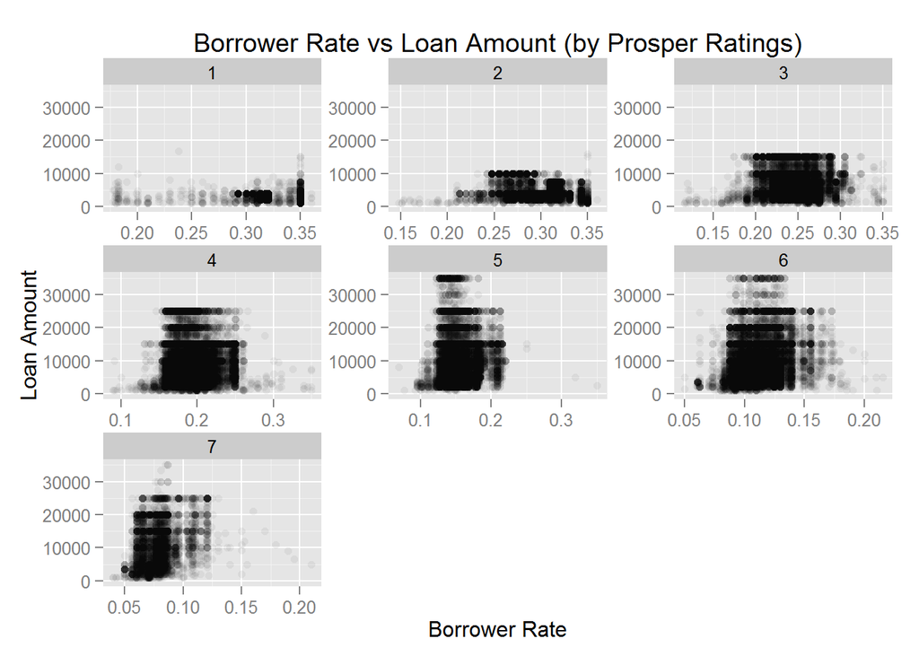

Loans with higher prosper rating have lower Borrower Rate. Borrowers with lower Prosper Rating usually are borrowing smaller amounts with higher rate. For better visualization I’ve used only loans created after 7/1/2009 because Prosper Rating was not available for loans before that date.

**Borrower Rate / Loan Amount / Prosper Rating by Income Range**

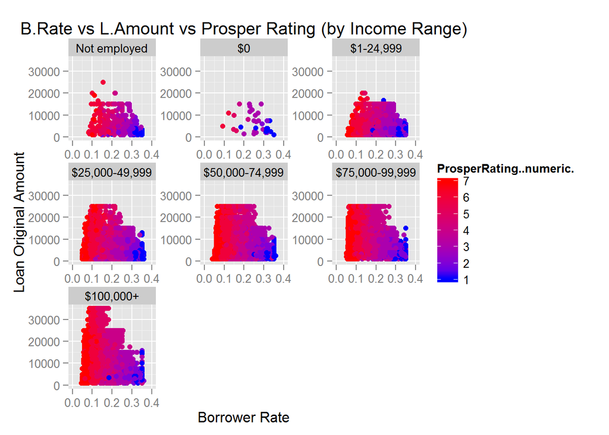

On these plots we can see how higher income range and higher Prosper rating leads to lower borrower rate. Bigger income range mean more loans with higher amount We can observe that as risk is lower the rate is smaller. For better visualization I’ve used only loans created after 7/1/2009 because Prosper score was not available for loans before that date.

**Borrower Rate / Income Range by Is Borrower Homeowner**

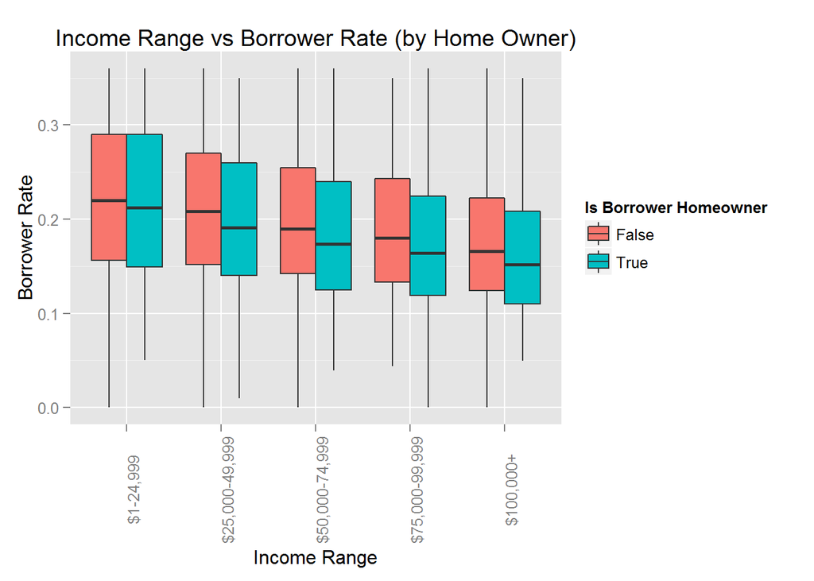

What we can observer from this graph is that borrowers with higher income who are home owners have lower borrower rates. For better visualization I’ve plotted the subset of data of all records that belonge to any valid income range (range > $0).

**Borrower Rate / Loan Amount / Prosper Score**

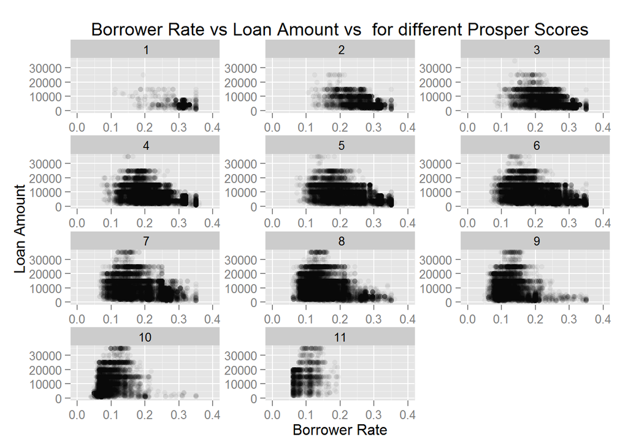

```
##    Min. 1st Qu.  Median    Mean 3rd Qu.    Max.    NA's
##    1.00    4.00    6.00    5.95    8.00   11.00   29084
```

On this plot we can observe that higher Prosper Score leads to lower Borrower rate. For better visualization I’ve plotted the subset of loans created after 7/1/2009 because Prosper score was not available for loans before that date.

# Multivariate Analysis

### Talk about some of the relationships you observed in this part of the investigation. Were there features that strengthened each other in terms of looking at your feature(s) of interest?

- Lower borrower rates is usually related to higher credit score, higher prosper score, higher prosper rating and owning home.
- Borrowers with lower Prosper Rating usually are borrowing small amounts with very high rate.
- Most of the borrowers have credit scores around 700.
- Higher income range and higher Prosper Rating leading to lower Borrower Rate.

### Were there any interesting or surprising interactions between features?

I think that most of the resualts I’ve observd were expected. Lower risk leads to lower borrower rate and higer interest for investig.

### OPTIONAL: Did you create any models with your dataset? Discuss the strengths and limitations of your model.

# Final Plots and Summary

### Plot One

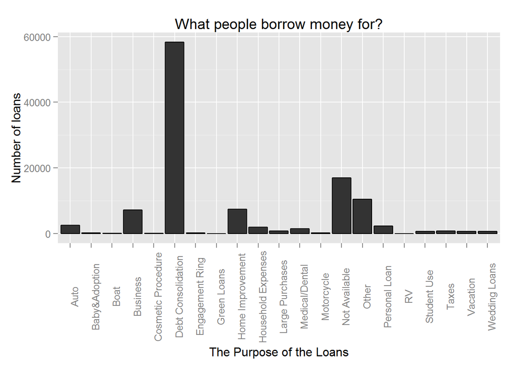

### Description One

On this plot we can see that the larger part of the loans are classified under debt consolidation. 58308 loans or around 51% are loans under debt consolidation category.

I’ve invastigated why this percent is so big, and I found that there are couple of reasons why people are borrowing money on Prosper for debt consolidation:

- Consolidating other high interest loans into one Prosper debt consolidation loan with a great rate, which leads to saving on amount of interest charged on other debts each month
- Prosper debt consolidation loans are so popular since they have a fixed interest rate
- Prosper offers only unsecured loans, so borrowers have no need to own home for debt consolidation
- To avoid bad credit, and maintain good credit score

### Plot Two

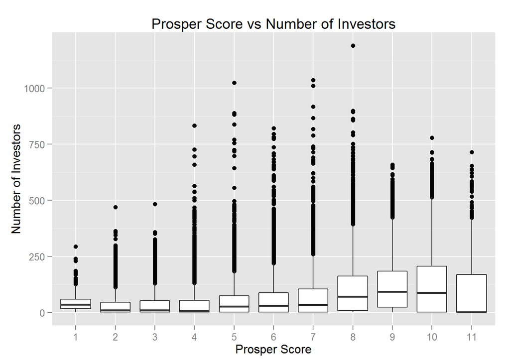

### Plot Three

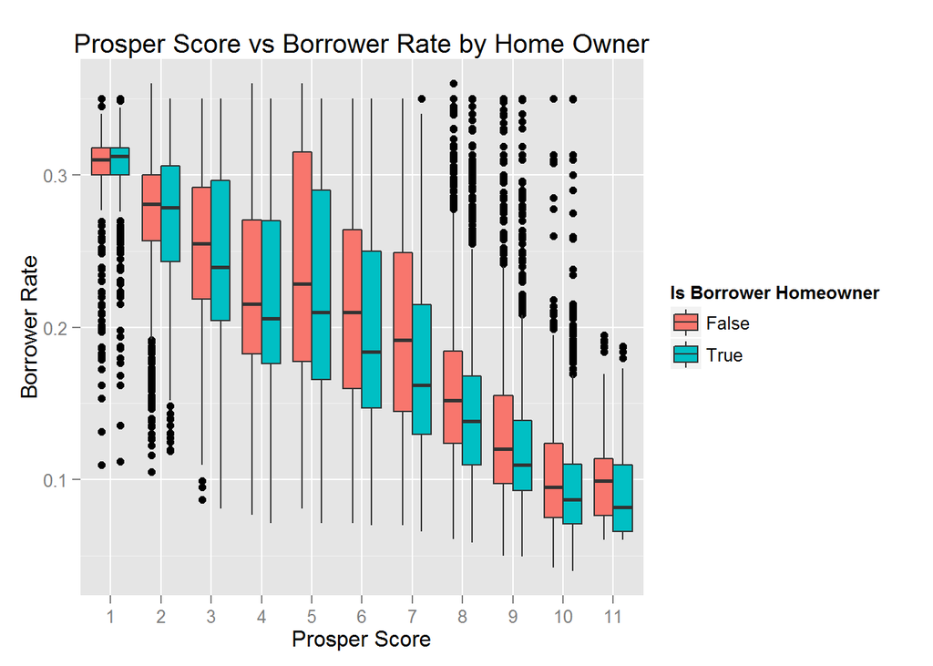

### Description Three

On this plot we can see trend of how higher Prosper scores and owning home leads to lower borrower rate. It’s good to have this information in case I need to borrow money using Prosper web site in the future. Owning home will provide me better borrower rate. For better visualization I’ve used the data subset loansAfter20090701, since Prosper Score was not available for loans before that date.

# Reflection

Before this project I didn’t know anything about Prosper and I was lightly knowledgeable about the peer-to-peer lending business process. That’s why when I was making my decision, which data set to analyse, white/red wine or Prosper one, I’ve decided to go with the Prosper data set and learn something more about it. My first reaction was “Well how can I analyse something that I have no idea how it works”, but after spending a lot of time on Prosper web site, and going over the variables in my excel sheet I’ve reached the feeling of being more and more knowledgeable and more confident in my analysis.

At the beginning I was struggling with the ggplot2 syntax, bat after a lot of practice, searching and reading on Google about the ggplot2 syntax I’ve become very comfortable with the basic ggplot2 syntax which helped me to create all these plots.

As a next step, I am planing to analyse some of the other variables that I didn’t covered in this analysis. I’m sure that I can learn more about this data set from the rest of the variables as well. Since my main focus on this project was exploratory analysis as a next step I would like to build predictive model. I would also like to contact Prosper and ask if they can provide me with the latest dataset (if it’s available for public), so I can compare my current observed trends vs the latest year trends. Were there any other major changes since march 2014, or the trends are the same.

To conclude, now after getting all this knowledge it’s much more easy to start any other analysis, do it much better and reach the next level. After my work in this project, what I really become more interested in is risk analysis.